# Annotating your corpus with the Stanford Dependency Parser

Author: Larissa Goulart, Northern Arizona University (lg845@nau.edu)  
Tested with CoreNLP 4.1.0

### **Before we start**

The goal of this workshop is to teach you how to annotate your corpus with the [Stanford Dependency Parser](https://stanfordnlp.github.io/CoreNLP/). In order to follow the workshop, you will need to download:

**1. CoreNLP**

- Download the [CoreNLP](https://www.dropbox.com/s/0hyzl8tl02tqv3t/stanford-corenlp-4.1.0.7z?dl=0) from https://stanfordnlp.github.io/CoreNLP/

[figure not shown]

- Unzip the files

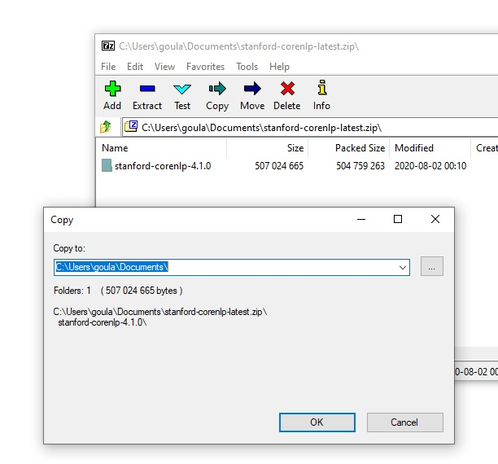

**2. Java**

- Stanford CoreNLP is written in Java. Therefore, you will need to have Java installed in your computer.You will need at least Java 8. Select the file to download according to your operating system https://java.com/en/download/manual.jsp
- *For windows users*:If you don’t know your computer’s operating system, you can click on *Windows/Start>Settings> System > About* to check.

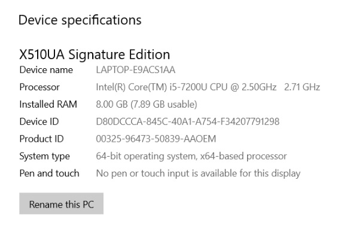

- *For mac users*: You will likely need to install [Java SE Development Kit](https://www.oracle.com/java/technologies/javase/javase-jdk8-downloads.html)

**3. Corpus Text Processor from [CROW](https://writecrow.org/)**

- Before running the Stanford CoreNLP, you will need to convert and standardize your text. For this, we will use the [Corpus Text Processor](https://github.com/writecrow/ciabatta/wiki/1.-Tools:-Corpus-Text-Processor#installation). You can read more about it [here](https://github.com/writecrow/ciabatta/wiki/1.-Tools:-Corpus-Text-Processor)

### **Overview**

Here is a general step by step of this workshop:

1.Introduction to the Stanford Dependency Parser

2.Preparing the files

3.Running the Stanford Dependency Parser

### **1.Introduction to the Stanford Dependency Parser**

The Stanford CoreNLP suite offers java-based tools to run a number of NLP basic tasks. CoreNLP is a toolkit updated frequently by the NLP research group at Stanford University. CoreNLP integrates the following tools:

1. [The part-of-speech tagger](https://nlp.stanford.edu/software/tagger.html)
2. [The named entity recognizer](https://nlp.stanford.edu/software/CRF-NER.html)
3. [The parser](https://nlp.stanford.edu/software/lex-parser.html)
4. [The coreference resolution system](https://nlp.stanford.edu/software/dcoref.html)
5. [Sentiment analysis](https://nlp.stanford.edu/sentiment/)  
   Among others

These tools allow us to extract linguistics annotations from our corpus, similar to what is seen below.

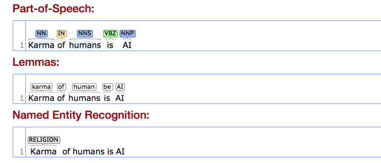

For corpus linguists, these annotations can be useful to conduct different types of analyses, such as, [key-feature analysis](https://www.youtube.com/watch?v=uQuEoeHlaEg), [multi-dimensional analysis](https://www.youtube.com/watch?v=tTdO1HJHUPM&feature=emb_title), and [machine learning applications](https://www.youtube.com/watch?v=MYn4qeyJsQw&feature=emb_title).

The two main annotators used for grammatical analysis are the part-of-speech tagger and the dependencies.

#### **1.1. Part-of-Speech Annotation**

Part-of-speech annotation gives you information about the word class of each word in a sentence.

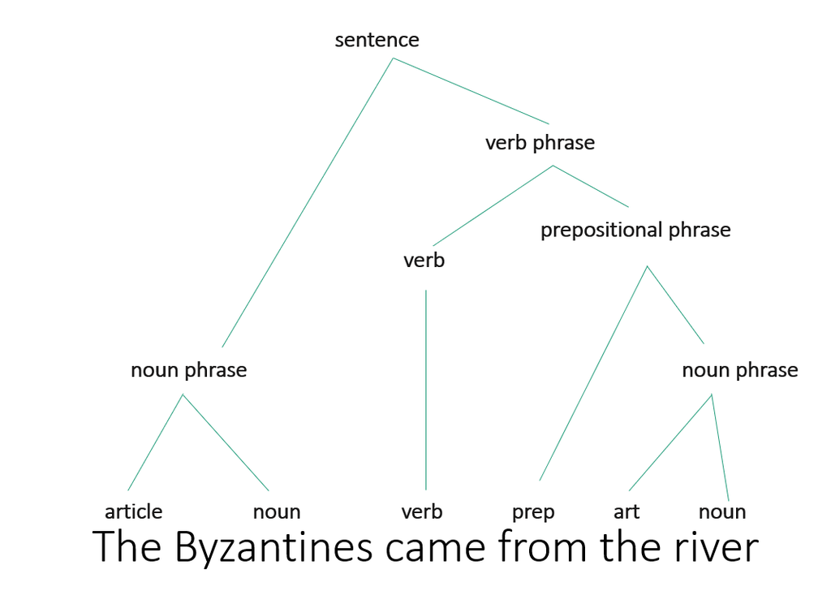

#### **1.2. Dependencies**

Dependencies indicate the syntactical relationship between the words in a sentence.

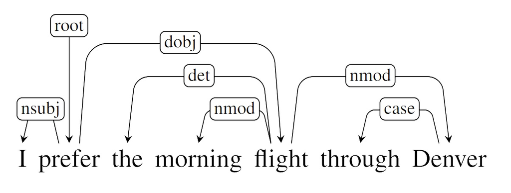

Jurafsky & Martin, 2019

###### Universal Stanford Dependencies are based on Universal Grammar. You can read more about them [here](https://nlp.stanford.edu/pubs/USD_LREC14_paper_camera_ready.pdf)

### **2.Preparing the files**

#### **2.1. Files: LILE Corpus**

For this workshop we will use ten files from the LILE Corpus [(Sarmento, Scortegagna & Goulart, 2011)](https://editora.pucrs.br//anais/sial/2011/src/29.pdf). This corpus contains abstracts of Thesis and Dissertations written in the fields of Literature and Applied Linguistics. You can download the files we will use [here](https://www.dropbox.com/s/b28f1nhwckuy99z/LILE_Corpus.7z?dl=0) or [here](https://www.dropbox.com/sh/pt9nxvlkaicxmfh/AADqKEO8zNSfwC_SsK1Vib5Ta?dl=0).

#### **2.2. [Corpus Text Processor](https://github.com/writecrow/ciabatta/wiki/1.-Tools:-Corpus-Text-Processor#installation)**

We will use CROW’s Corpus Text Processor to prepare the files. I recommend that you create three folders in your computer that mirror the menus in the Corpus Text Processor: 01_converted, 02_encoded, and 03_standardized before running the tool. It should look like this.

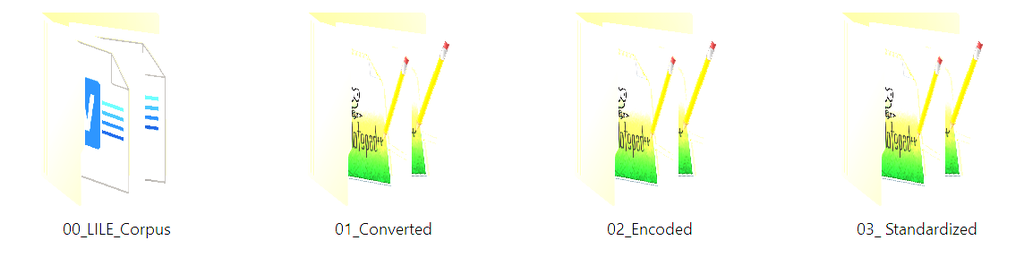

And this is what you will see when you open the Corpus Text Processor

[figure not shown]

To convert the files, we will follow the order of the menus in the Corpus Text Processor. You can also watch the [video demonstration](https://drive.google.com/file/d/1xMiHrJzF1L5kjS3wVGVIF8OmlQQ5iI4q/view) on how to run it.

Now, we have all the files in the correct format to run the Stanford Dependency Parser.

### **3.Running the Stanford Dependency Parser**

#### **3.1. Checking the Java settings**

In order to run CoreNLP, you will need to allocate more RAM memory to Java than your computer’s default setting. If you have a lot of RAM this will not be a problem for you.You can check this by going to *Windows/Start>Settings> System > About* again.

When explaining the memory needed to run CoreNLP, the Stanford NLP group said that:

> CoreNLP needs about 2GB to run the entire pipeline.

Let’s allocate more RAM to Java in your machine.

1. Open your Control Panel

2. Select Programs

[figure not shown]

3. Select Java

4. Click on the tab Java

[figure not shown]

5. Change the Runtime Parameter

[figure not shown]

6. Decide on the most suitable parameter

-Xmx512m assigns 512MB memory for Java.  
-Xmx1024m assigns 1GB memory for Java.  
-Xmx2048m assigns 2GB memory for Java.  
-Xmx3072m assigns 3GB memory for Java  
And so on…

You can start with *-Xmx3072m* and if CoreNLP does not work try *-Xmx2048m* and so on. Keep in mind that as you assign more memory to Java, CoreNLP will run faster.

7. Click OK on the “Java Runtime” window and then Apply in the “Java Control Panel”

###### [Alternative tutorial on how to assign more RAM to Java](http://www.messiahpsychoanalyst.org/wikihow/index.php/How_to_Increase_Java_Memory_in_Windows)

###### To understand why CoreNLP needs more memory than other applications, you can check the developers’ explanation [here](https://stanfordnlp.github.io/CoreNLP/memory-time.html).

#### **3.2. Navigating to the *stanford-corenlp-full* folder**

Windows:

1. Open *Power Shell ISE*

[figure not shown]

Mac:

1. Open your Terminal

*Launchpad > Terminal*

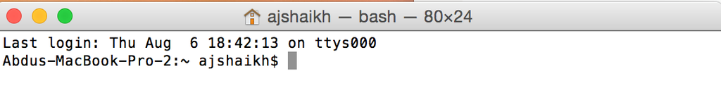

[figure not shown]

3. Use `cd` to navigate to the directory where you saved the *stanford-corenlp-full* folder

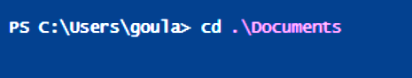

If you run into an error, check that you are doing `cd` + space + the name of the folder. You can also use tab to autocomplete the name of the directory.

Once you find the folder you are looking for, press Enter

This is how it should look on a **Windows** machine

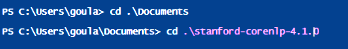

This is how it should look on a **Mac**

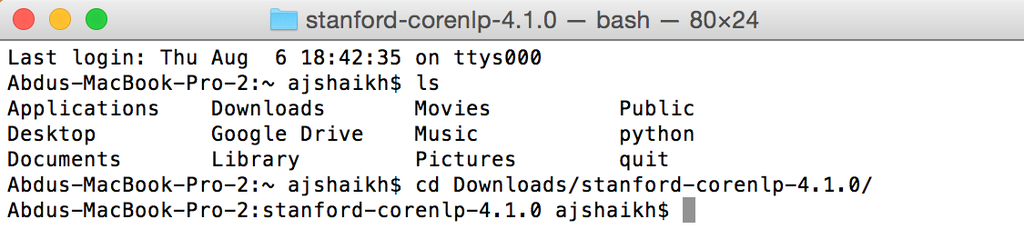

I saved the *stanford-corenlp-full* folder in my documents. So, in my computer, this is the code:

`cd Documents\stanford-corenlp-4.1.0`

#### **3.3. Launching CoreNLP (optional)**

After navigating to the CoreNLP folder, we are going to run this code.

`java -mx4g -cp "*" edu.stanford.nlp.pipeline.StanfordCoreNLPServer [port] [timeout]`

Where `-mx4g` indicates the amount of RAM that CoreNLP can use. So, if you set 3GB to Java you can use `-mx3g` and so on.

It should look like this:

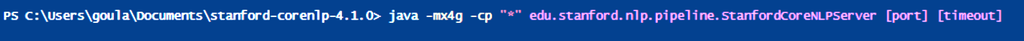

Then, open `http://localhost:9000` in your machine and see if an interface like this will open.

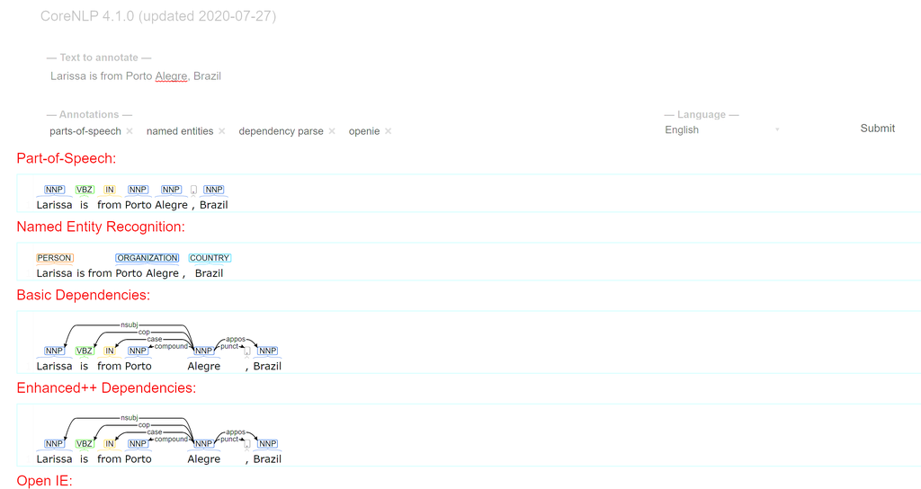

#### **3.4. Running CoreNLP in one file**

The previous code opens the CoreNLP interface. With the interface, you can analyze one sentence at a time, but if you want to annotate the whole text, this is the code we will use:

`java -mx3g -cp "*" edu.stanford.nlp.pipeline.StanfordCoreNLP -file` filename_here `-outputFormat conll`

Where *filename_here* is the name of your file and `-mx3gp` is the amount of RAM you assigned to Java. In addition, make sure to write the path between inverted commas " ".

**Windows**

This is an example of the code on a **Windows**:

`java -mx3g -cp "*" edu.stanford.nlp.pipeline.StanfordCoreNLP` `-file '..\LAEL_Research_Bazaar\Corpus Text Processor\03_Standardized\LIRNLGI101.txt'` `-outputFormat conll`

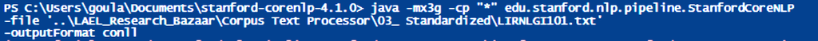

**Mac**

This is an example of the code on a **Mac**:

`java -mx3g -cp "*" edu.stanford.nlp.pipeline.StanfordCoreNLP` `-file '../LAEL_Research_Bazaar/Corpus Text Processor/03_Standardized/LIRNLGI101.txt'` `-outputFormat conll`

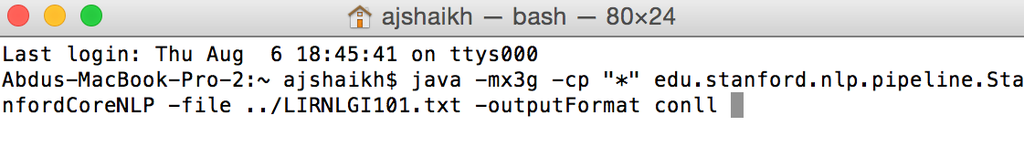

Where `..\` means that I am going back one folder.

It will take a couple of seconds to annotate the text.

After running CoreNLP, your file should look like this

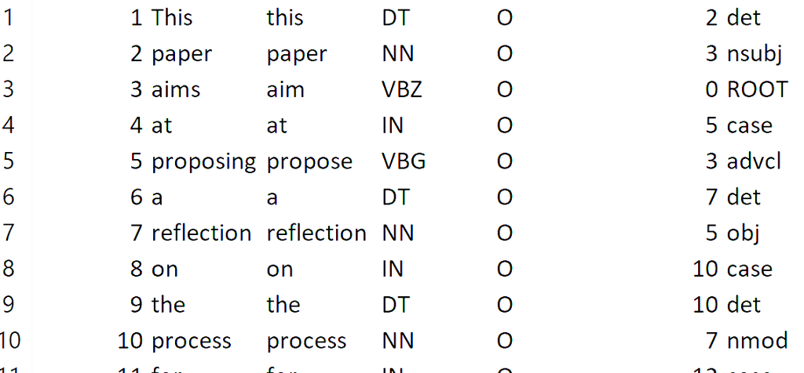

#### **3.5. Running CoreNLP in a directory**

While annotating one file may be all you need, usually, for corpus linguistics analysis, you will have to annotate several texts in a directory.

**Windows**

To annotate a whole directory, this is the code you will use for **Windows**:

`Get-ChildItem "` input_Directory `" -Filter *.txt |Foreach-Object {java -mx3g -cp "*" edu.stanford.nlp.pipeline.StanfordCoreNLP -file$_.FullName -outputDirectory “` output_Directory `” -outputFormat conll}`

Make sure to write the *input* and the *output* path between inverted commas " ".

This is an example of the code on a **Windows**:

`Get-ChildItem "..\LAEL_Research_Bazaar\Corpus Text Processor\03_Standardized" -Filter *.txt` `|Foreach-Object {java -mx3g -cp "*" edu.stanford.nlp.pipeline.StanfordCoreNLP -file $_.FullName` `-outputDirectory "..\LAEL_Research_Bazaar\tagged" -outputFormat conll}`

Here is what it should look like in your PowerShell ISE:

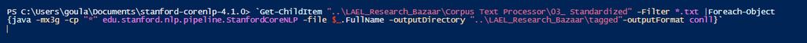

**Mac**

This is the code you will use for a **Mac**:

`for i in` input_directory `/*.txt; do (java -mx3g -cp "*" edu.stanford.nlp.pipeline.StanfordCoreNLP -file $i -outputDirectory “` output_Directory `” -outputFormat conll); done`

Make sure to write the *input* and the *output* path between inverted commas " ".

This is an example of the code on a **Mac**:

`for i in ../LAEL_Research_Bazaar/Corpus Text Processor/03_Standardized/*.txt; do (java -mx3g -cp` `"*" edu.stanford.nlp.pipeline.StanfordCoreNLP -file $i -outputDirectory` `"../LAEL_Research_Bazaar/tagged" -outputFormat conll); done`

#### **3.6. Annotators available**

In the previous step, we ran CoreNLP annotating our texts for lemmas, part-of-speech, entity recognition and dependencies, but CoreNLP offers many other tools.You can see the full list of annotators here https://stanfordnlp.github.io/CoreNLP/annotators.html

To change the annotators we are using, we will add the flag `-annotators` plus the annotators we would like to run. For example, the code

**Windows**  
`java -mx3g -cp "*" edu.stanford.nlp.pipeline.StanfordCoreNLP -annotators tokenize,ssplit,pos -file` `'..\LAEL_Research_Bazaar\Corpus Text Processor\03_Standardized\LIRNLGI101.txt' -outputFormat conll`

**Mac**  
`java -mx3g -cp "*" edu.stanford.nlp.pipeline.StanfordCoreNLP -annotators tokenize,ssplit,pos -file` `'../LAEL_Research_Bazaar/Corpus Text Processor/03_Standardized/LIRNLGI101.txt' -outputFormat conll`

will run only the tokenizer, the sentence split and the part-of-speech annotators.

Now, the output will look like this:

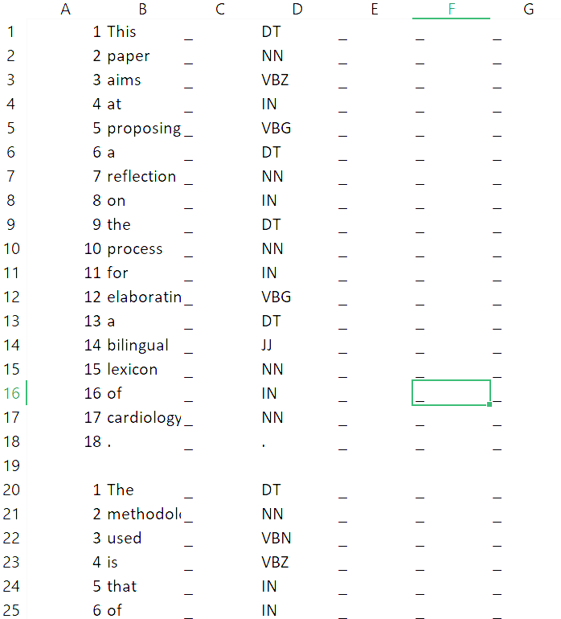

Example: sentiment analysis

Let’s say you want to extract sentiment analysis, all you have to do is to include the sentiment annotators in the flag `-annotators` and change the `outputFormat` to xml.

**Windows**  
`java -mx3g -cp "*" edu.stanford.nlp.pipeline.StanfordCoreNLP -annotators` `tokenize,ssplit,pos,parse,sentiment -file '..\LAEL_Research_Bazaar\Corpus Text Processor\03_Standardized\LIRNLGI101.txt' -outputFormat xml`

**Mac**  
`java -mx3g -cp "*" edu.stanford.nlp.pipeline.StanfordCoreNLP -annotators` `tokenize,ssplit,pos,parse,sentiment -file '../LAEL_Research_Bazaar/Corpus Text Processor/03_Standardized/LIRNLGI101.txt' -outputFormat xml`

Note that there are dependencies between annotators. Thus, to run the sentiment analysis annotator, you need to run the tokenizer, the sentence split, the part of speech tagger and the parser also.

Just remember the more annotators you include, the longer it will take to annotate each text.

#### **3.7. Flags key**

We can think about the flags as items in a menu. Here is a dictionary for the different flags we used.

`-annotators`: we choose the annotators we want to use.  
`-file`: we indicate the file that will be annotated.  
`-outputFormat`: we select the format of the file that is output with the tags.  
`-props`: we can use props to indicate the language we are annotating.  
`-outputDirectory`: we choose the folder where we are going to save the texts.

#### **3.8. Reading the output**

The output with lemmas, part-of-speech tags, recognized entities and dependencies will look like this:

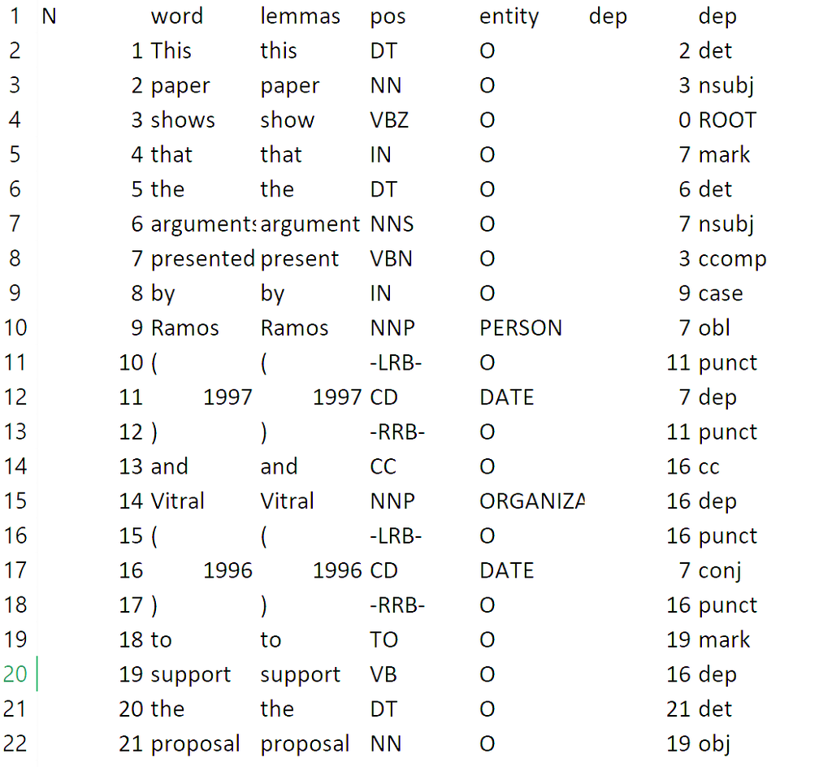

CC Coordinating conjunction  
CD Cardinal number  
DT Determiner  
EX Existential there  
FW Foreign word  
IN Preposition or subordinating conjunction  
JJ Adjective  
JJR Adjective, comparative  
JJS Adjective, superlative  
LS List item marker  
MD Modal  
NN Noun, singular or mass  
NNS Noun, plural  
NNP Proper noun, singular  
NNPS Proper noun, plural  
PDT Predeterminer  
POS Possessive ending  
PRP Personal pronoun  
PRP$ Possessive pronoun  
RB Adverb  
RBR Adverb, comparative  
RBS Adverb, superlative  
RP Particle  
SYM Symbol  
TO to  
UH Interjection  
VB Verb, base form  
VBD Verb, past tense  
VBG Verb, gerund or present participle  
VBN Verb, past participle  
VBP Verb, non3rd person singular present  
VBZ Verb, 3rd person singular present  
WDT Wh-determiner  
WP Wh pronoun  
WP$ Possessive wh-pronoun  
WRB Wh-adverb

In English, CoreNLP recognizes  
PERSON  
LOCATION  
ORGANIZATION  
MISC  
MONEY  
NUMBER  
ORDINAL  
PERCENT DATE  
TIME  
DURATION  
SET

#### **3.9. Annotating other languages**

To annotate texts in other languages, first you need to download the properties for the language you want to use. Find the correct file [here](https://stanfordnlp.github.io/CoreNLP/).

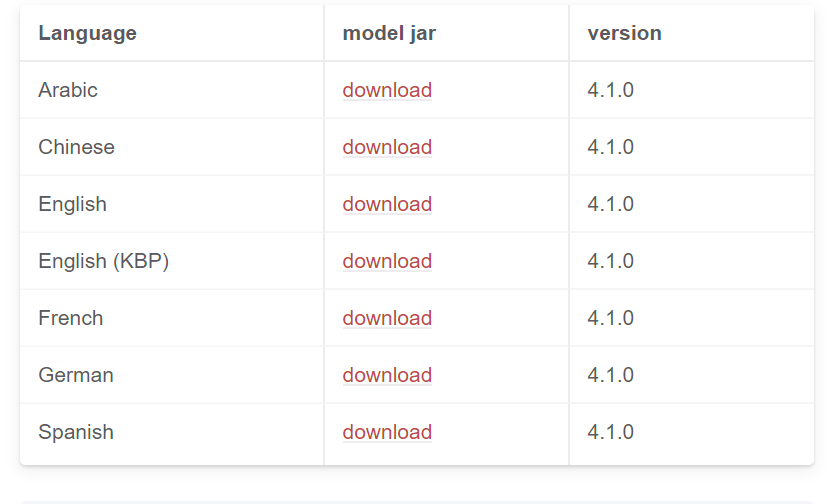

Let’s practice with one file in [Spanish](https://www.dropbox.com/s/sdrqnejjgomq81f/spanish.txt?dl=0). Here is the code you will need to run:

`java -mx3g -cp "*" edu.stanford.nlp.pipeline.StanfordCoreNLP -Spanish.properties -file` *filename_here* `-outputFormat conll`

Example **Windows**  
`java -mx3g -cp "*" edu.stanford.nlp.pipeline.StanfordCoreNLP -props StanfordCoreNLP-spanish.properties -file '..\spanish.txt' -outputFormat conll`

**Mac**  
`java -mx3g -cp "*" edu.stanford.nlp.pipeline.StanfordCoreNLP -props StanfordCoreNLP-spanish.properties -file '../spanish.txt' -outputFormat conll`

#### **Ideas on how to count the tags**

*Antconc*

We can use [Antconc](https://www.laurenceanthony.net/software/antconc/) to look at the texts and count the tags.

You can do this by opening Antconc > File > Open File > Change *files of type* for *All Files* > add all texts.

[figure not shown]

*RStudio*

We can also use RStudio, as an example you could use this code to count the tags:

`library(tidyverse)`  
`file_path <- "tagged/LIRNLGI101.txt.conll"`

`file <- read_tsv(file_path,`  
`col_names = FALSE,`  
`skip_empty_rows = FALSE)`  
`tags <- file %>%`  
`count(X4)`  
`View(tags)`  
`write_csv(tags, "tags.csv")`

**List of Resources**

[NLP with Stanford CoreNLP](https://cloudacademy.com/blog/natural-language-processing-stanford-corenlp/)  
[Stanford CoreNLP Tutorial](https://interviewbubble.com/stanford-corenlp-tutorial/)  
[Stanford CoreNLP](http://www.linguisticsweb.org/doku.php?id=linguisticsweb:tutorials:linguistics_tutorials:automaticannotation:stanford_core_nlp)  
[Processing multiple files in a directory](http://www.linguisticsweb.org/doku.php?id=linguisticsweb:tutorials:linguistics_tutorials:automaticannotation:stanford_core_nlp_multiple_files)  
[Taylor et al.](http://citeseerx.ist.psu.edu/viewdoc/download?doi=10.1.1.9.8216&rep=rep1&type=pdf)